# Twitter Analysis about new Omicron Variant

This project discusses the latest Omicron Variant of COVID-19 virus. The dataset was collected from Twitter and was updated on December 16th with recent tweets about the new Omicron Variant of COVID-19. The dataset depict the feeling of users towards the latest Omicron Variant. The goal of our project is visualizing user feelings and descriptive trends in Twitter about Omicron topics.

```python
#general purpose packages
import numpy as np
import pandas as pd
import matplotlib.pyplot as plt
import seaborn as sns
```

### Data Import

```python
# Customize filename
filename = "/Users/michiganboy/Documents/course1/assets/omicron.csv"
omicron = pd.read_csv(filename)
```

```python
omicron
```

|  | id | user_name | user_location | user_description | user_created | user_followers | user_friends | user_favourites | user_verified | date | text | hashtags | source | retweets | favorites | is_retweet |
| --- | --- | --- | --- | --- | --- | --- | --- | --- | --- | --- | --- | --- | --- | --- | --- | --- |
| 0 | 1465693385088323591 | Abaris | Hants | Would appear on Blogger (did originally), but... | 2009-09-16 14:30:32 | 2880 | 4369 | 26907 | False | 2021-11-30 14:45:08 | @SkyNews "Told you I'd be Back!" #OMICRON “Odi... | ['OMICRON'] | Twitter Web App | 0 | 0 | False |
| 1 | 1465693062999412746 | GFTs  | Lalaland | There's a field somewhere beyond all doubt and... | 2019-12-28 14:29:13 | 165 | 583 | 21152 | False | 2021-11-30 14:43:52 | Someone told me this in October #Omicron https... | ['Omicron'] | Twitter for Android | 0 | 0 | False |
| 2 | 1465690116442279942 | Herbie Finkle (Cozy) | NaN | help me find me frens ❤️ | 2021-07-10 09:40:57 | 114 | 393 | 2339 | False | 2021-11-30 14:32:09 | Glad to see the public schoolkids are wrapping... | ['COVID'] | Twitter Web App | 0 | 1 | False |
| 3 | 1465689607165591552 | Electrical Review | United Kingdom | Electrical Review is a monthly journal aimed a... | 2009-05-21 08:32:19 | 20759 | 2321 | 739 | False | 2021-11-30 14:30:08 | #Automation systems have become increasingly c... | ['Automation'] | Hootsuite Inc. | 0 | 0 | False |
| 4 | 1465688203709464578 | BingX Academy 🔑 | NaN | BingX (Prev. Bingbon) is the world's top crypt... | 2013-12-31 02:57:32 | 17134 | 8 | 31 | False | 2021-11-30 14:24:33 | 🟢 If u think Omicron is a FUD, you LONG📈\n🔴 If... | NaN | Twitter Web App | 2 | 2 | False |
| ... | ... | ... | ... | ... | ... | ... | ... | ... | ... | ... | ... | ... | ... | ... | ... | ... |
| 39163 | 1471495763880386560 | Mahaan | NaN | Matured Dalapathy fan from kerala❤ Dancer of k... | 2021-10-13 10:04:38 | 24 | 57 | 1963 | False | 2021-12-16 15:01:43 | @aanakattil_ @arunjlak1 Anils insecurity about... | ['Thala'] | Twitter for Android | 3 | 4 | False |
| 39164 | 1471495731005427718 | Allison Bell | New York, NY | Covers life & health insurance for @TA_LifeHea... | 2009-08-19 14:33:37 | 6980 | 7677 | 6725 | False | 2021-12-16 15:01:35 | View&gt;Evidence that a big #Omicron wave is s... | ['Omicron'] | Twitter for iPhone | 0 | 0 | False |
| 39165 | 1471495729772306447 | Alan | Ontario, Canada | 🇨🇦 | 2011-10-10 19:58:08 | 431 | 665 | 17564 | False | 2021-12-16 15:01:35 | More than double the cases for vaccinated than... | NaN | Twitter Web App | 0 | 1 | False |
| 39166 | 1471495686105759750 | Douglas MacDonald | Jeju Island, South Korea | Canadian 🇨🇦 photojournalist living in #Jeju #S... | 2009-10-26 02:27:06 | 6136 | 2622 | 2314 | False | 2021-12-16 15:01:25 | How does #Omicron spread so fast? Virus may no... | ['Omicron'] | Twitter for Android | 0 | 0 | False |
| 39167 | 1471495681940492296 | Garreth McDaid | Leitrim, Ireland | #Bitcoin | 2009-03-23 17:02:45 | 1601 | 803 | 11868 | False | 2021-12-16 15:01:24 | I can understand people wanting #omicron to be... | ['omicron'] | Twitter Web App | 0 | 59 | False |

39168 rows × 16 columns

```python
omicron.describe()
```

|  | id | user_followers | user_friends | user_favourites | retweets | favorites |
| --- | --- | --- | --- | --- | --- | --- |
| count | 3.916800e+04 | 3.916800e+04 | 39168.000000 | 3.916800e+04 | 39168.000000 | 39168.000000 |
| mean | 1.468352e+18 | 2.041943e+05 | 1678.257251 | 1.731431e+04 | 1.814874 | 6.091018 |
| std | 1.988668e+15 | 1.278784e+06 | 8965.896558 | 5.144423e+04 | 14.194947 | 47.194959 |
| min | 1.465648e+18 | 0.000000e+00 | 0.000000 | 0.000000e+00 | 0.000000 | 0.000000 |
| 25% | 1.466591e+18 | 1.190000e+02 | 96.000000 | 3.110000e+02 | 0.000000 | 0.000000 |
| 50% | 1.468111e+18 | 8.170000e+02 | 423.000000 | 2.075500e+03 | 0.000000 | 1.000000 |
| 75% | 1.470467e+18 | 5.436250e+03 | 1437.000000 | 1.255650e+04 | 1.000000 | 2.000000 |
| max | 1.471584e+18 | 1.645623e+07 | 384929.000000 | 1.376481e+06 | 877.000000 | 2376.000000 |

```python
omicron.info()
```

```
<class 'pandas.core.frame.DataFrame'>
RangeIndex: 39168 entries, 0 to 39167
Data columns (total 16 columns):
 #   Column            Non-Null Count  Dtype
---  ------            --------------  -----
 0   id                39168 non-null  int64
 1   user_name         39168 non-null  object
 2   user_location     30289 non-null  object
 3   user_description  36808 non-null  object
 4   user_created      39168 non-null  object
 5   user_followers    39168 non-null  int64
 6   user_friends      39168 non-null  int64
 7   user_favourites   39168 non-null  int64
 8   user_verified     39168 non-null  bool
 9   date              39168 non-null  object
 10  text              39168 non-null  object
 11  hashtags          28915 non-null  object
 12  source            39168 non-null  object
 13  retweets          39168 non-null  int64
 14  favorites         39168 non-null  int64
 15  is_retweet        39168 non-null  bool
dtypes: bool(2), int64(6), object(8)
memory usage: 4.3+ MB
```

### Question 2: How many tweets are disseminated per day? On which day witnessed the highest and lowest number of tweets about Omicron?

```python
tweets_per_day = (pd.to_datetime(omicron['date'])
                  .dt.strftime('%m-%d')
                  .value_counts()
                  .sort_index()
                  .reset_index(name='counts')
                 )
```

```python
tweets_per_day
```

|  | index | counts |
| --- | --- | --- |
| 0 | 11-30 | 3168 |
| 1 | 12-01 | 3000 |
| 2 | 12-02 | 3000 |
| 3 | 12-03 | 3185 |
| 4 | 12-04 | 2815 |
| 5 | 12-05 | 3000 |
| 6 | 12-07 | 4346 |
| 7 | 12-08 | 1654 |
| 8 | 12-10 | 1141 |
| 9 | 12-11 | 1859 |
| 10 | 12-13 | 3000 |
| 11 | 12-14 | 3000 |
| 12 | 12-15 | 3000 |
| 13 | 12-16 | 3000 |

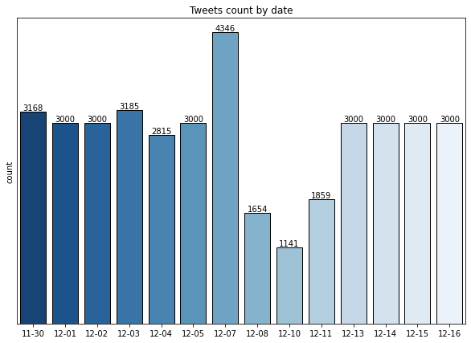

```python
### BEGIN SOLUTION

plt.figure(figsize=(10,7))
ax = sns.barplot(x='index', y='counts', data=tweets_per_day,edgecolor = 'black',ci=False, palette='Blues_r')
plt.title('Tweets count by date')
plt.yticks([])
ax.bar_label(ax.containers[0])
plt.ylabel('count')
plt.xlabel('')

### END SOLUTION
```

What trend do you see about Twitter posts about Omicron?

### Question 3: How many tweets are disseminated in each hour throughout all days? On which hour witnessed the highest and lowest number of tweets about Omicron?

```python
# The code of retrieving the number of tweets per hour could be retrieved from this code.
tweets_per_hour = (pd.to_datetime(omicron['date'])
                  .dt.strftime('%H')
                  .value_counts()
                  .sort_index()
                  .reset_index(name='counts')
                 )
```

```python
tweets_per_hour
```

|  | index | counts |
| --- | --- | --- |
| 0 | 00 | 1090 |
| 1 | 01 | 1216 |
| 2 | 02 | 1385 |
| 3 | 03 | 1960 |
| 4 | 04 | 2018 |
| 5 | 05 | 2033 |
| 6 | 06 | 2612 |
| 7 | 07 | 2516 |
| 8 | 08 | 1994 |
| 9 | 09 | 2008 |
| 10 | 10 | 2216 |
| 11 | 11 | 3240 |
| 12 | 12 | 2924 |
| 13 | 13 | 1805 |
| 14 | 14 | 1922 |
| 15 | 15 | 985 |
| 16 | 16 | 1002 |
| 17 | 17 | 1091 |
| 18 | 18 | 1098 |
| 19 | 19 | 1108 |
| 20 | 20 | 1284 |
| 21 | 21 | 466 |
| 22 | 22 | 559 |
| 23 | 23 | 636 |

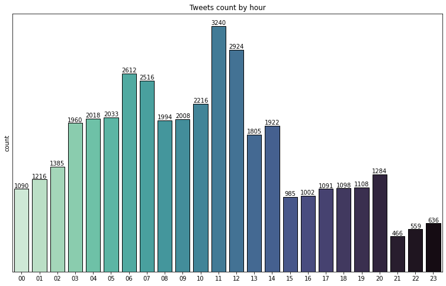

```python
### BEGIN SOLUTION

plt.figure(figsize=(13, 8))
ax = sns.barplot(x='index', y='counts', data=tweets_per_hour,edgecolor = 'black',ci=False, palette='mako_r')
plt.title('Tweets count by hour')
plt.yticks([])
ax.bar_label(ax.containers[0])
plt.ylabel('count')
plt.xlabel('')

### END SOLUTION
```

What trend do you see about Twitter posts about Omicron?